# R Notebook

```r
library(tidyverse); library(lubridate); library(gganimate)
set.seed(42)
sample <- tibble(
  dates = seq.Date(from = ymd(20160701), to   = ymd(20181001), by = "day"),
  chg   = runif(length(dates), min = -10, max = 10),
  cuml  = cumsum(chg)
)
```

Let’s plot the series, along with a smoothed version. `geom_smooth` has a parameter called “span” that determines how much of the series should be averaged into each point.

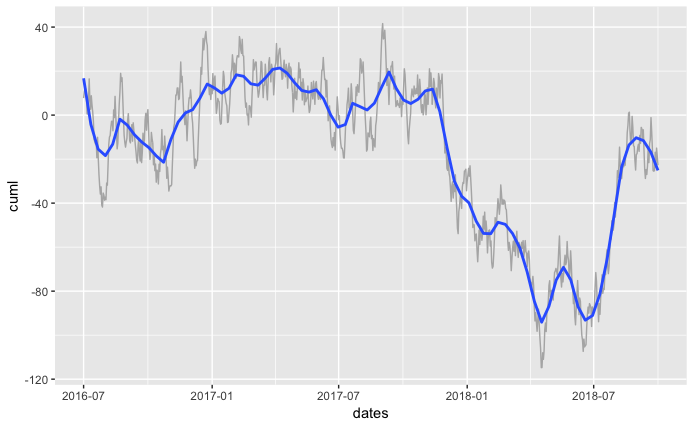

I’d like to animate how much smoothing there is. * Possible to animate span parameter of geom_smooth directly? * Alternatively, create new columns with smoothed data, gather, and transition those…

```r
sample %>%
  mutate(smoothed = loess(cuml ~ dates), sample)
```

```
NAs introduced by coercionError in mutate_impl(.data, dots) :
  Evaluation error: NA/NaN/Inf in foreign function call (arg 2).
```

I’m curious what the series would look like if it appeared on the edge of a rotating cylinder, like a phonograph record or a seismograph. This will require a few translations:

- x axis should be wrapped around, so that each period (could be one day, or one week, or one month, or one year) is shown as one cycle. I think the mapping would be a sin function, so that the earliest values are mapped to x = 0, increasing linearly at first, until one quarter of the period (PI/2 in radians?), represented at max x.
- y could be adjustable, using height * -cos(phase), to allow for flat head-on viewing when height = 0, or some height to look at the cylinder from a different height.

```r
animate(a, nframes = 200)
```

[output not shown]

[output cut: 262 more lines]

[output not shown]

To make this look cooler, I’d rather have the whole cylinder rotate, leaving the current point visible. This seems possible if we prepare the data first, calculating each frame and shfting the visibility and phase according to frame.

This worked well and I tweeted it out on 10/6/18.

```r
animate(b, nframes = 200, fps = 20, width = 300, height = 150) #, renderer = av_renderer())
```

[output not shown]

[output cut: 258 more lines]

[output not shown]

```r
# Change fps to 20+ for smoother motion
animate(b, fps = 25, duration = 15, width = 300, height = 150)
```

```
geom_path: Each group consists of only one observation. Do you need to adjust the group aesthetic?
geom_path: Each group consists of only one observation. Do you need to adjust the group aesthetic?
```

[output not shown]

[output cut: 463 more lines]

[output not shown]

Getting closer. Something’s a little buggy so lemme try rewriting another way

```r
gall_att <- readr::read_csv("~/Downloads/gallery_attendance (1).csv") %>%
  mutate(dates = mdy(Date),
         paid = `Gallery Attendance` * `Paid %`)
```

```r
df_longer <- add_cyclic_data(sample %>% filter(dates > max(dates) - 900))

# cycle_length <- 365

b <- ggplot(df_longer, aes(x_pos, cuml, alpha = -distance, color = dates)) +
  geom_path(aes(size = -days_ago)) +
  # geom_vline(data = df_longer %>% filter(dates > max(dates) - cycle_length),
  #            aes(xintercept = x_pos), color = "gray50", alpha = 0.1) +

  geom_vline(data = df_longer %>% filter(month(dates) %in% c(1, 4, 7, 10), day(dates) == 1),
             aes(xintercept = x_pos, alpha = -distance), color = "gray50", lty = "dashed") +
  scale_size(range = c(0,2)) +
  transition_manual(id) + theme_void() +
  guides(size = "none", alpha = "none", color = "none")

animate(b, nframes = 300, fps = 20, width = 300, height = 150) #, renderer = av_renderer())
```

[output not shown]

```r
animate(b, nframes = 10, duration = 10, width = 400, height = 250) #, renderer = av_renderer())
```

[output not shown]

[output not shown]

[output cut: 842 more lines]

# Storms version

Perhaps the same technique could be applied to a standard R data set, like dplyr’s storms.

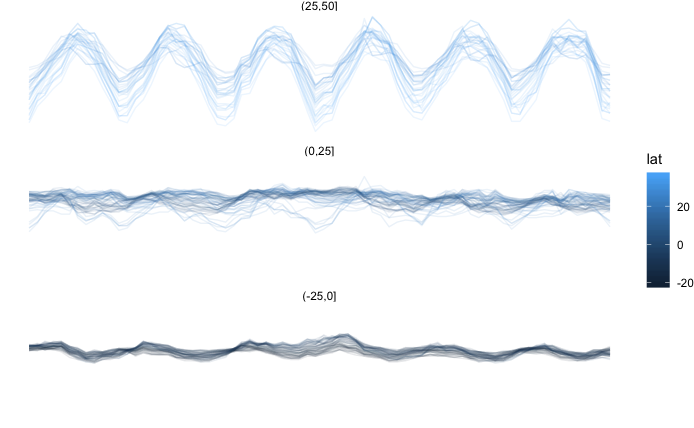